# Project Python Foundations: FoodHub Data Analysis

**Marks: 60**

### Context

The number of restaurants in New York is increasing day by day. Lots of students and busy professionals rely on those restaurants due to their hectic lifestyles. Online food delivery service is a great option for them. It provides them with good food from their favorite restaurants. A food aggregator company FoodHub offers access to multiple restaurants through a single smartphone app.

The app allows the restaurants to receive a direct online order from a customer. The app assigns a delivery person from the company to pick up the order after it is confirmed by the restaurant. The delivery person then uses the map to reach the restaurant and waits for the food package. Once the food package is handed over to the delivery person, he/she confirms the pick-up in the app and travels to the customer's location to deliver the food. The delivery person confirms the drop-off in the app after delivering the food package to the customer. The customer can rate the order in the app. The food aggregator earns money by collecting a fixed margin of the delivery order from the restaurants.

### Objective

The food aggregator company has stored the data of the different orders made by the registered customers in their online portal. They want to analyze the data to get a fair idea about the demand of different restaurants which will help them in enhancing their customer experience. Suppose you are hired as a Data Scientist in this company and the Data Science team has shared some of the key questions that need to be answered. Perform the data analysis to find answers to these questions that will help the company to improve the business.

### Data Description

The data contains the different data related to a food order. The detailed data dictionary is given below.

### Data Dictionary

- order_id: Unique ID of the order
- customer_id: ID of the customer who ordered the food
- restaurant_name: Name of the restaurant
- cuisine_type: Cuisine ordered by the customer
- cost: Cost of the order
- day_of_the_week: Indicates whether the order is placed on a weekday or weekend (The weekday is from Monday to Friday and the weekend is Saturday and Sunday)
- rating: Rating given by the customer out of 5
- food_preparation_time: Time (in minutes) taken by the restaurant to prepare the food. This is calculated by taking the difference between the timestamps of the restaurant's order confirmation and the delivery person's pick-up confirmation.
- delivery_time: Time (in minutes) taken by the delivery person to deliver the food package. This is calculated by taking the difference between the timestamps of the delivery person's pick-up confirmation and drop-off information

### Let us start by importing the required libraries

```python
# import libraries for data manipulation
import numpy as np
import pandas as pd

# import libraries for data visualization
import matplotlib.pyplot as plt
import seaborn as sns
```

### Understanding the structure of the data

```python
# uncomment and run the following lines for Google Colab
from google.colab import drive
drive.mount('/content/drive')
```

```python
# read the data
df = pd.read_csv('/content/drive/My Drive/Colab Notebooks/foodhub_order.csv')
# returns the first 5 rows
df.head()
```

|  | order_id | customer_id | restaurant_name | cuisine_type | cost_of_the_order | day_of_the_week | rating | food_preparation_time | delivery_time |
| --- | --- | --- | --- | --- | --- | --- | --- | --- | --- |
| 0 | 1477147 | 337525 | Hangawi | Korean | 30.75 | Weekend | Not given | 25 | 20 |
| 1 | 1477685 | 358141 | Blue Ribbon Sushi Izakaya | Japanese | 12.08 | Weekend | Not given | 25 | 23 |
| 2 | 1477070 | 66393 | Cafe Habana | Mexican | 12.23 | Weekday | 5 | 23 | 28 |
| 3 | 1477334 | 106968 | Blue Ribbon Fried Chicken | American | 29.20 | Weekend | 3 | 25 | 15 |
| 4 | 1478249 | 76942 | Dirty Bird to Go | American | 11.59 | Weekday | 4 | 25 | 24 |

#### Observations:

The DataFrame has 9 columns as mentioned in the Data Dictionary. Data in each row corresponds to the order placed by a customer.

### **Question 1:** How many rows and columns are present in the data? [0.5 mark]

```python
# Returns the number of rows and columns in the dataset

df.shape
```

```
(1898, 9)
```

#### Observations:

There are 1898 rows and 9 columns in the DataFrame.

### **Question 2:** What are the datatypes of the different columns in the dataset? (The info() function can be used) [0.5 mark]

```python
# Use info() to print a concise summary of the DataFrame
df.info()
```

```
<class 'pandas.core.frame.DataFrame'>
RangeIndex: 1898 entries, 0 to 1897
Data columns (total 9 columns):
 #   Column                 Non-Null Count  Dtype
---  ------                 --------------  -----
 0   order_id               1898 non-null   int64
 1   customer_id            1898 non-null   int64
 2   restaurant_name        1898 non-null   object
 3   cuisine_type           1898 non-null   object
 4   cost_of_the_order      1898 non-null   float64
 5   day_of_the_week        1898 non-null   object
 6   rating                 1898 non-null   object
 7   food_preparation_time  1898 non-null   int64
 8   delivery_time          1898 non-null   int64
dtypes: float64(1), int64(4), object(4)
memory usage: 133.6+ KB
```

#### Observations:

There is 1 float datatype, 4 int datatypes and 4 object data types in the data set.

```python
#returns the unique values from the rating column
df['rating'].unique()
```

```
array(['Not given', '5', '3', '4'], dtype=object)
```

### **Question 3:** Are there any missing values in the data? If yes, treat them using an appropriate method. [1 mark]

```python
# Returns the sum of all the missing values in the dataset
df.isnull().sum()
```

|  | 0 |
| --- | --- |
| order_id | 0 |
| customer_id | 0 |
| restaurant_name | 0 |
| cuisine_type | 0 |
| cost_of_the_order | 0 |
| day_of_the_week | 0 |
| rating | 0 |
| food_preparation_time | 0 |
| delivery_time | 0 |

**dtype:** int64

#### Observations:

There are no missing values in the dataset and hence do not require any treatment methods.

### **Question 4:** Check the statistical summary of the data. What is the minimum, average, and maximum time it takes for food to be prepared once an order is placed? [2 marks]

```python
# Returns the statistical summary of the data
df.describe().T
```

|  | count | mean | std | min | 25% | 50% | 75% | max |
| --- | --- | --- | --- | --- | --- | --- | --- | --- |
| order_id | 1898.0 | 1.477496e+06 | 548.049724 | 1476547.00 | 1477021.25 | 1477495.50 | 1.477970e+06 | 1478444.00 |
| customer_id | 1898.0 | 1.711685e+05 | 113698.139743 | 1311.00 | 77787.75 | 128600.00 | 2.705250e+05 | 405334.00 |
| cost_of_the_order | 1898.0 | 1.649885e+01 | 7.483812 | 4.47 | 12.08 | 14.14 | 2.229750e+01 | 35.41 |
| food_preparation_time | 1898.0 | 2.737197e+01 | 4.632481 | 20.00 | 23.00 | 27.00 | 3.100000e+01 | 35.00 |
| delivery_time | 1898.0 | 2.416175e+01 | 4.972637 | 15.00 | 20.00 | 25.00 | 2.800000e+01 | 33.00 |

#### Observations:

Based on the above summary, The minimum time taken to prepare the food after placing an order is 20 min. The average food prepartion time is approximately 27.4 minutes The maximum time to prepare food is 35 minutes

### **Question 5:** How many orders are not rated? [1 mark]

```python
# Returns the count of the orders in the rating column
df['rating'].value_counts()
```

| rating | count |
| --- | --- |
| Not given | 736 |
| 5 | 588 |
| 4 | 386 |
| 3 | 188 |

**dtype:** int64

#### Observations:

There are 736 orders in the data set which were not given a rating.

### Exploratory Data Analysis (EDA)

### **Question 6:** Explore all the variables and provide observations on their distributions. (Generally, histograms, boxplots, countplots, etc. are used for univariate exploration.) [9 marks]

```python
df.info()
```

```
<class 'pandas.core.frame.DataFrame'>
RangeIndex: 1898 entries, 0 to 1897
Data columns (total 9 columns):
 #   Column                 Non-Null Count  Dtype
---  ------                 --------------  -----
 0   order_id               1898 non-null   int64
 1   customer_id            1898 non-null   int64
 2   restaurant_name        1898 non-null   object
 3   cuisine_type           1898 non-null   object
 4   cost_of_the_order      1898 non-null   float64
 5   day_of_the_week        1898 non-null   object
 6   rating                 1898 non-null   object
 7   food_preparation_time  1898 non-null   int64
 8   delivery_time          1898 non-null   int64
dtypes: float64(1), int64(4), object(4)
memory usage: 133.6+ KB
```

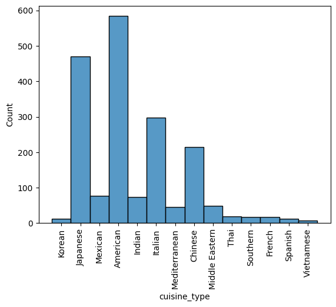

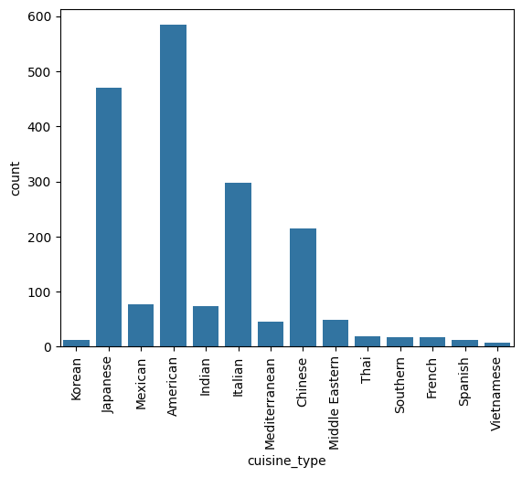

```python
# Observations on cuisine_type

sns.histplot(data=df,x='cuisine_type')
plt.xticks(rotation=90)
plt.show()
sns.countplot(data=df,x='cuisine_type')
plt.xticks(rotation=90)
plt.show()
```

```python
df['cuisine_type'].value_counts().head(5)
```

| cuisine_type | count |
| --- | --- |
| American | 584 |
| Japanese | 470 |
| Italian | 298 |
| Chinese | 215 |
| Mexican | 77 |

**dtype:** int64

Observations on the cuisine type:

Based on the above plots, American cuisine is the most preferred cuisine type followed by Japanese, Italian and Chinese

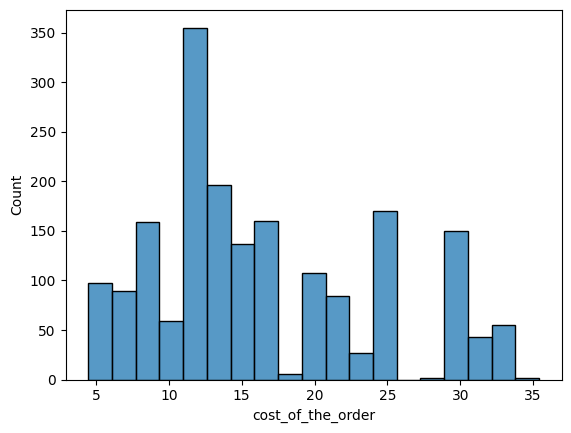

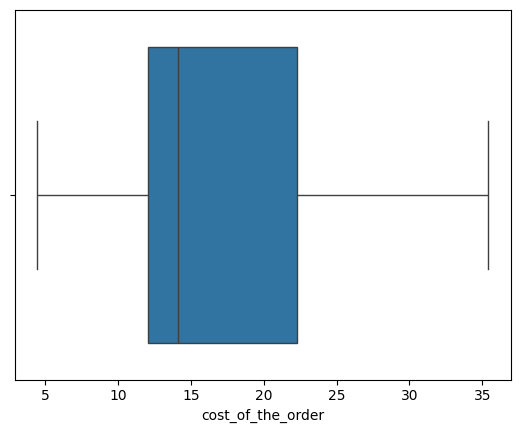

```python
# Observations on cost_of_the_order

sns.histplot(data=df,x='cost_of_the_order')
plt.show()
sns.boxplot(data=df,x='cost_of_the_order')
plt.show()
```

```python
# To find the percentage of the orders that cost between 10 and 20 dollars

(df[(df.cost_of_the_order >10) & (df.cost_of_the_order < 20)] ['order_id'].count()/df.shape[0])*100
```

```
50.0
```

Observations on the cost_of_the_order

1. The data looks right-skewed
2. 50% of the total orders placed cost between 10 and 20 dollars

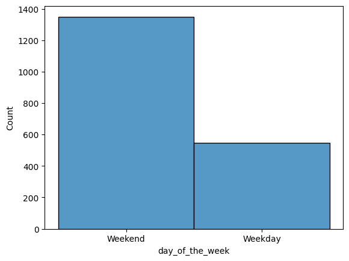

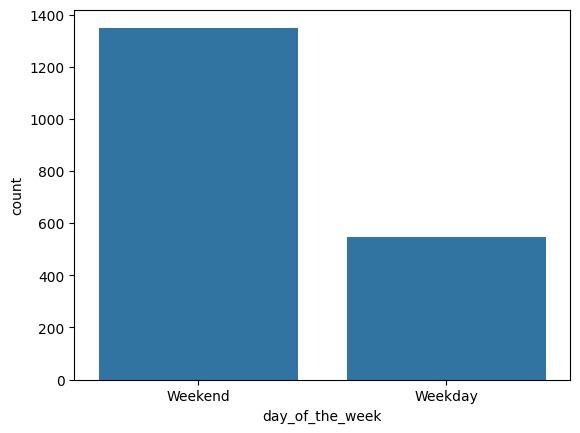

```python
#Observations based on the day of the week
sns.histplot(data=df,x='day_of_the_week')
plt.show()
sns.countplot(data=df,x='day_of_the_week')
plt.show()
```

```python
#Returns the total number of orders placed based on the day of the week
df['day_of_the_week'].value_counts()
```

| day_of_the_week | count |
| --- | --- |
| Weekend | 1351 |
| Weekday | 547 |

**dtype:** int64

Observations:

More than 70% of the orders are placed on a Weekend

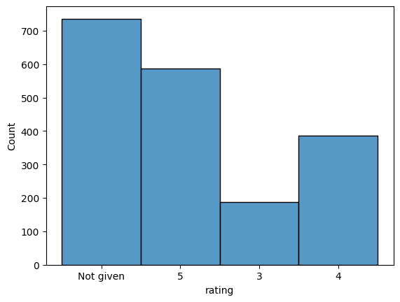

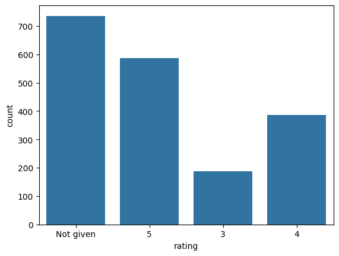

```python
#Observations based on the rating
sns.histplot(data=df,x='rating')
plt.show()
sns.countplot(data=df,x='rating')
plt.show()
```

```python
df['rating'].value_counts()
```

| rating | count |
| --- | --- |
| Not given | 736 |
| 5 | 588 |
| 4 | 386 |
| 3 | 188 |

**dtype:** int64

Observations: Based on the above data, 736 orders were not given any rating by the customers.

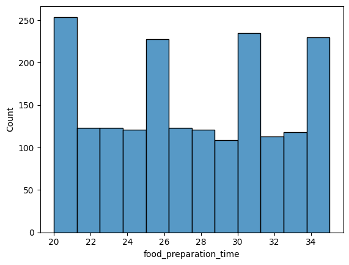

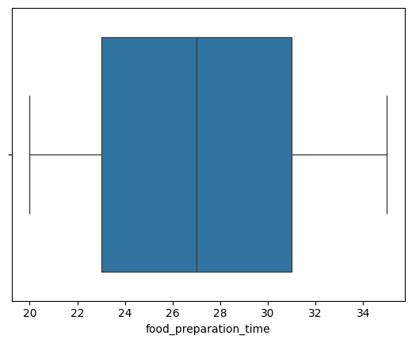

```python
#Observations based on the time taken to prepare the food

sns.histplot(data=df,x='food_preparation_time')
plt.show()
sns.boxplot(data=df,x='food_preparation_time')
plt.show()
```

```python
df['food_preparation_time'].describe().T
```

|  | food_preparation_time |
| --- | --- |
| count | 1898.000000 |
| mean | 27.371970 |
| std | 4.632481 |
| min | 20.000000 |
| 25% | 23.000000 |
| 50% | 27.000000 |
| 75% | 31.000000 |
| max | 35.000000 |

**dtype:** float64

Observations:

The data looks uniformly distributed with an average food preparation time of about 27 minutes.

The maximum time taken to prepare the food is about 35 minutes.

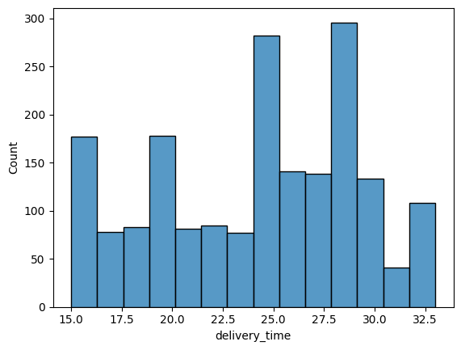

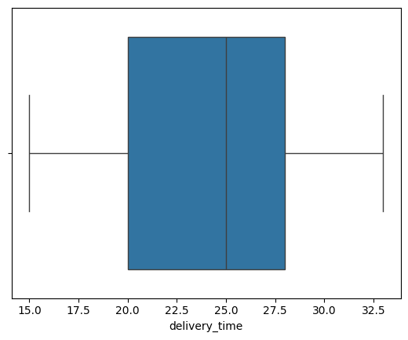

```python
#Observations based on the time taken to deliver the food to the customer

sns.histplot(data=df,x='delivery_time')
plt.show()
sns.boxplot(data=df,x='delivery_time')
plt.show()
```

```python
df['delivery_time'].describe().T
```

|  | delivery_time |
| --- | --- |
| count | 1898.000000 |
| mean | 24.161749 |
| std | 4.972637 |
| min | 15.000000 |
| 25% | 20.000000 |
| 50% | 25.000000 |
| 75% | 28.000000 |
| max | 33.000000 |

**dtype:** float64

```python
#Percentage of orders that are delivered between 20 and 30 minutes
round((df[(df.delivery_time >20) & (df.delivery_time < 30)] ['order_id'].count()/df.shape[0])*100, 2)
```

```
57.96
```

Observations:

The data looks skewed to the left with an average of 25 minutes to deliver the food

Most of the orders are delivered between 20-30 minutes

### **Question 7**: Which are the top 5 restaurants in terms of the number of orders received? [1 mark]

```python
# Returns the count of all the unique orders received by the top 5 restaurants

df['restaurant_name'].value_counts().nlargest(5)
```

| restaurant_name | count |
| --- | --- |
| Shake Shack | 219 |
| The Meatball Shop | 132 |
| Blue Ribbon Sushi | 119 |
| Blue Ribbon Fried Chicken | 96 |
| Parm | 68 |

**dtype:** int64

The top 5 restaurants as per the number of orders received are : Shake Shack, The Meatball Shop, Blu Ribbon Sushi, Blue Ribbon Fried Chicken and Parm.

### **Question 8**: Which is the most popular cuisine on weekends? [1 mark]

```python
# To filter the weekend orders and to return the cusinies with the most number of orders
df[df.day_of_the_week=='Weekend'].cuisine_type.value_counts().head(5)
```

| cuisine_type | count |
| --- | --- |
| American | 415 |
| Japanese | 335 |
| Italian | 207 |
| Chinese | 163 |
| Mexican | 53 |

**dtype:** int64

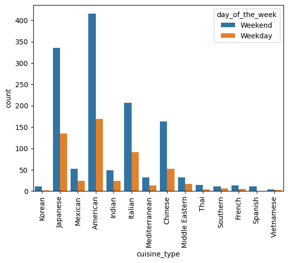

```python
sns.countplot(data=df,x='cuisine_type',hue = 'day_of_the_week')
plt.xticks(rotation=90);
plt.show()
```

#### Observations:

As per the data generated in the dataset as well as the above histogram plot, the American cuision is the most ordered on weekends with count of 415 times.

### **Question 9**: What percentage of the orders cost more than 20 dollars? [2 marks]

```python
# Returns the percentage of all the orders that cost more than 20 dollars
round(len(df[df['cost_of_the_order']>20])/len(df)*100,2)
```

```
29.24
```

#### Observations:

The percentage of orders that cost more than 20 dollars is 29.24.

### **Question 10**: What is the mean order delivery time? [1 mark]

```python
# Returns the mean time to deliver the order

round(df['delivery_time'].mean(),2)
```

```
24.16
```

#### Observations:

The mean order delivery time is 24.16 which mean the average time taken to deliver the order to the customer is 24.16 minutes.

### **Question 11:** The company has decided to give 20% discount vouchers to the top 5 most frequent customers. Find the IDs of these customers and the number of orders they placed. [1 mark]

```python
# Returns the customer IDs of the most frequent along with the number of orders they placed
df['customer_id'].value_counts().head(5)
```

| customer_id | count |
| --- | --- |
| 52832 | 13 |
| 47440 | 10 |
| 83287 | 9 |
| 250494 | 8 |
| 259341 | 7 |

**dtype:** int64

#### Observations:

The customers with IDs 52832, 47440,83287,250494 and 259341 are eligible to receive the 20% discount vouchers based on the frequency of their orders.

### **Question 12**: Perform a multivariate analysis to explore relationships between the important variables in the dataset. (It is a good idea to explore relations between numerical variables as well as relations between numerical and categorical variables) [10 marks]

```python
# Write the code here
df.info()
```

```
<class 'pandas.core.frame.DataFrame'>
RangeIndex: 1898 entries, 0 to 1897
Data columns (total 9 columns):
 #   Column                 Non-Null Count  Dtype
---  ------                 --------------  -----
 0   order_id               1898 non-null   int64
 1   customer_id            1898 non-null   int64
 2   restaurant_name        1898 non-null   object
 3   cuisine_type           1898 non-null   object
 4   cost_of_the_order      1898 non-null   float64
 5   day_of_the_week        1898 non-null   object
 6   rating                 1898 non-null   object
 7   food_preparation_time  1898 non-null   int64
 8   delivery_time          1898 non-null   int64
dtypes: float64(1), int64(4), object(4)
memory usage: 133.6+ KB
```

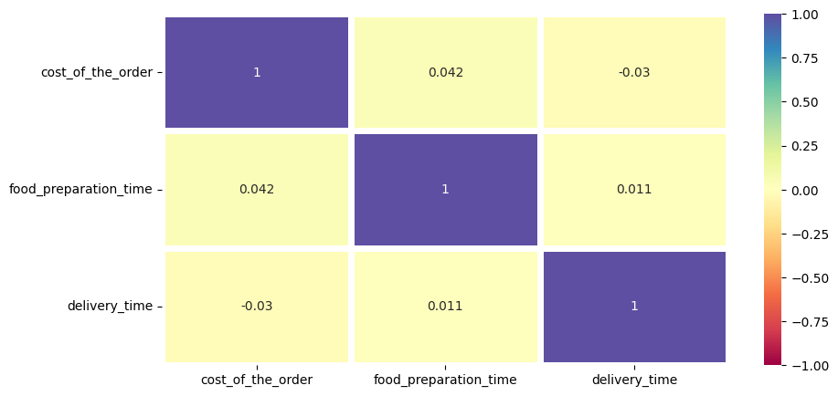

```python
#Multivariate analysis on numberical data
#Correlation between variables using a heatmap

col_list = ['cost_of_the_order','food_preparation_time','delivery_time']
plt.figure(figsize=(10,5))
sns.heatmap(df[col_list].corr(),annot=True,cmap='Spectral',vmin=-1,vmax=1,linewidths=5)
plt.show()
```

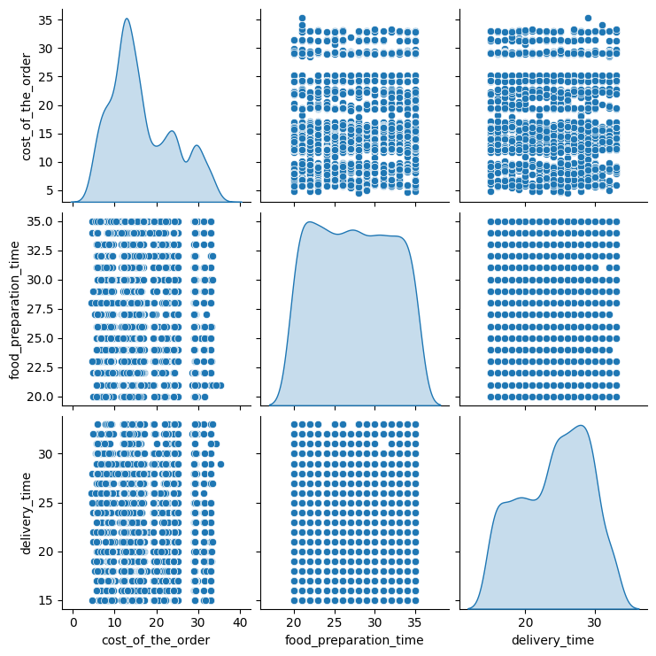

```python
#Pairplot for the numerical variables in the dataset
#returns pairplot of the dataset
sns.pairplot(data= df[col_list], diag_kind='kde')
plt.show()
```

Observations:

There appears to be no correlation between the 3 numerical variables cost_of_the_order, food_preparation_time and delivery_time.

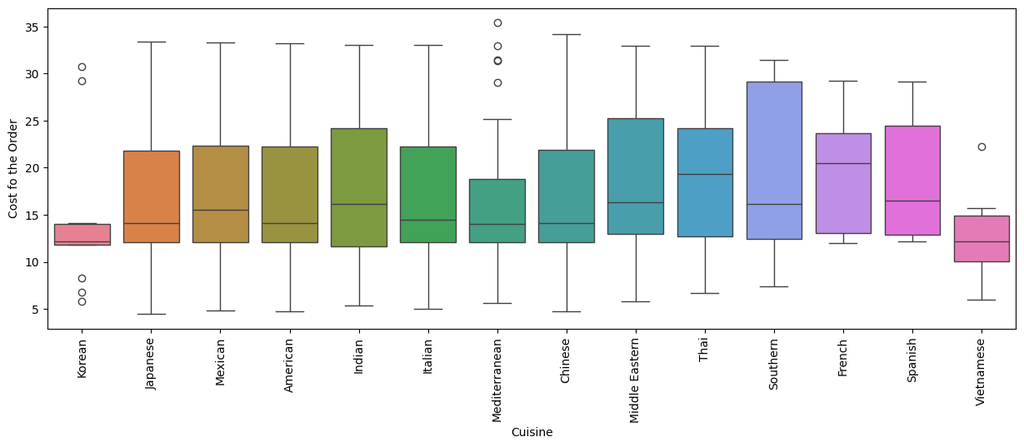

```python
#Bivariate analysis on categorical data using boxplots
plt.figure(figsize=(15,5))
sns.boxplot(data=df,x='cuisine_type',y='cost_of_the_order',hue='cuisine_type')
plt.xticks(rotation=90);
plt.xlabel('Cuisine')
plt.ylabel('Cost fo the Order')
plt.show()
```

Observations:

Based on the above boxplot, most of the cuisine types cost between 10 and 25 dollars except for a few outliers (mediterranean cuisine)

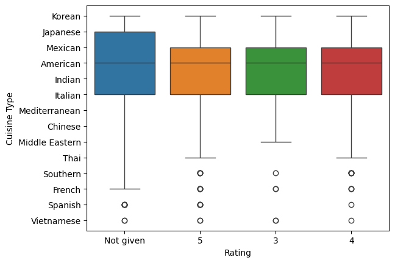

```python
#Bivariate analysis based on cuisine_type and rating
sns.boxplot(data=df,x='rating',y='cuisine_type', hue ='rating')
plt.yticks(rotation =0)
plt.xlabel('Rating')
plt.ylabel('Cuisine Type')
plt.show()
```

```python
df.groupby(['cuisine_type'])['rating'].value_counts()
```

| cuisine_type | rating | count |
| --- | --- | --- |
| American | Not given | 216 |
|  | 5 | 174 |
|  | 4 | 130 |
|  | 3 | 64 |
| Chinese | Not given | 82 |
|  | 5 | 69 |
|  | 4 | 40 |
|  | 3 | 24 |
| French | Not given | 8 |
|  | 5 | 5 |
|  | 4 | 3 |
|  | 3 | 2 |
| Indian | 5 | 32 |
|  | Not given | 23 |
|  | 4 | 13 |
|  | 3 | 5 |
| Italian | Not given | 126 |
|  | 5 | 90 |
|  | 4 | 54 |
|  | 3 | 28 |
| Japanese | Not given | 197 |
|  | 5 | 142 |
|  | 4 | 91 |
|  | 3 | 40 |
| Korean | 4 | 4 |
|  | Not given | 4 |
|  | 5 | 3 |
|  | 3 | 2 |
| Mediterranean | 5 | 16 |
|  | Not given | 14 |
|  | 3 | 9 |
|  | 4 | 7 |
| Mexican | Not given | 29 |
|  | 5 | 26 |
|  | 4 | 16 |
|  | 3 | 6 |
| Middle Eastern | 4 | 16 |
|  | Not given | 15 |
|  | 5 | 13 |
|  | 3 | 5 |
| Southern | 4 | 7 |
|  | 5 | 5 |
|  | Not given | 4 |
|  | 3 | 1 |
| Spanish | Not given | 6 |
|  | 5 | 5 |
|  | 4 | 1 |
| Thai | Not given | 10 |
|  | 5 | 6 |
|  | 4 | 3 |
| Vietnamese | 3 | 2 |
|  | 5 | 2 |
|  | Not given | 2 |
|  | 4 | 1 |

**dtype:** int64

Observations:

Based on the orders that were rated, American cuisine has the most ratings followed by Japanese cuisine.

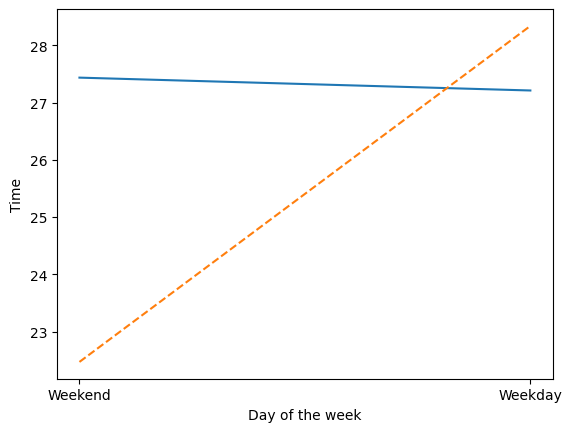

```python
#Bivariate analysis based on the day of the week and total time to deliver the food
sns.lineplot(data=df,x='day_of_the_week',y='food_preparation_time',errorbar=None)
sns.lineplot(data=df,x='day_of_the_week',y='delivery_time',errorbar=None, linestyle='dashed')
plt.xlabel('Day of the week')
plt.ylabel('Time')
plt.show();
```

Observations:

Based on the above line plot, there is a very little difference in the time taken to prepare the order to the customer based on the day of the week

The delivery time during a Weekday is more than that during a Weekend

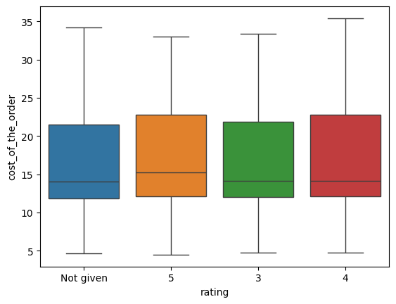

```python
#Bivariate analysis based on the rating and cost of the order

sns.boxplot(data=df, x='rating', y ='cost_of_the_order', hue='rating')
plt.yticks(rotation=0);
plt.show()
```

### **Question 13:** The company wants to provide a promotional offer in the advertisement of the restaurants. The condition to get the offer is that the restaurants must have a rating count of more than 50 and the average rating should be greater than 4. Find the restaurants fulfilling the criteria to get the promotional offer. [3 marks]

```python
#Filters the 'Not Given' ratings from the data
df_rated = df[df['rating'] != 'Not given'].copy()
```

```python
df_rated
```

|  | order_id | customer_id | restaurant_name | cuisine_type | cost_of_the_order | day_of_the_week | rating | food_preparation_time | delivery_time |
| --- | --- | --- | --- | --- | --- | --- | --- | --- | --- |
| 2 | 1477070 | 66393 | Cafe Habana | Mexican | 12.23 | Weekday | 5 | 23 | 28 |
| 3 | 1477334 | 106968 | Blue Ribbon Fried Chicken | American | 29.20 | Weekend | 3 | 25 | 15 |
| 4 | 1478249 | 76942 | Dirty Bird to Go | American | 11.59 | Weekday | 4 | 25 | 24 |
| 5 | 1477224 | 147468 | Tamarind TriBeCa | Indian | 25.22 | Weekday | 3 | 20 | 24 |
| 7 | 1477859 | 89574 | Barbounia | Mediterranean | 5.97 | Weekday | 3 | 33 | 30 |
| ... | ... | ... | ... | ... | ... | ... | ... | ... | ... |
| 1889 | 1478190 | 94152 | RedFarm Broadway | Chinese | 8.68 | Weekday | 3 | 33 | 30 |
| 1890 | 1477316 | 164776 | TAO | Japanese | 15.67 | Weekend | 5 | 20 | 22 |
| 1893 | 1476701 | 292602 | Chipotle Mexican Grill $1.99 Delivery | Mexican | 22.31 | Weekend | 5 | 31 | 17 |
| 1894 | 1477421 | 397537 | The Smile | American | 12.18 | Weekend | 5 | 31 | 19 |
| 1896 | 1477513 | 64151 | Jack's Wife Freda | Mediterranean | 12.18 | Weekday | 5 | 23 | 31 |

1162 rows × 9 columns

```python
#Returns the count of the ratings given to the restaurants
df_rated.groupby(['restaurant_name'])['rating'].value_counts().nlargest(10)
```

| restaurant_name | rating | count |
| --- | --- | --- |
| Shake Shack | 5 | 60 |
| The Meatball Shop | 5 | 53 |
| Shake Shack | 4 | 50 |
| Blue Ribbon Fried Chicken | 5 | 32 |
| Blue Ribbon Sushi | 5 | 32 |
|  | 4 | 25 |
| Shake Shack | 3 | 23 |
| Blue Ribbon Fried Chicken | 4 | 21 |
| The Meatball Shop | 4 | 21 |
| RedFarm Broadway | 5 | 18 |

**dtype:** int64

```python
#Converts the object data type to int
df_rated['rating'] = pd.to_numeric(df_rated['rating'], errors='coerce')
```

```python
df_req = df_rated.groupby(['restaurant_name'])['rating'].agg(['mean', 'count'])
```

```python
df_req[(df_req['mean'] > 4) & (df_req['count'] > 50)]
```

| restaurant_name | mean | count |
| --- | --- | --- |
| Blue Ribbon Fried Chicken | 4.328125 | 64 |
| Blue Ribbon Sushi | 4.219178 | 73 |
| Shake Shack | 4.278195 | 133 |
| The Meatball Shop | 4.511905 | 84 |

#### Observations:

The restaurants that have an average rating > 4 and a rating count more than 50 are Blue Ribbon Fried Chicken, Blue Ribbon Sushi, Shake Shack and The Meatball shop.

### **Question 14:** The company charges the restaurant 25% on the orders having cost greater than 20 dollars and 15% on the orders having cost greater than 5 dollars. Find the net revenue generated by the company across all orders. [3 marks]

```python
# To find the sum of the orders that are greater than 20 dollars
above_20 = df[df['cost_of_the_order'] > 20]
above_20['cost_of_the_order'].sum()

# To find the sum of the orders that are greater than 5 dollars but less than or equal to 20 dollars
above_5 = df[(df['cost_of_the_order'] >5) & (df['cost_of_the_order'] <= 20 )]
above_5['cost_of_the_order'].sum()

#Net revenue of the company

net_revenue = (above_20['cost_of_the_order'].sum())*0.25 + (above_5['cost_of_the_order'].sum())*0.15
print(net_revenue)
```

```
6166.303
```

#### Observations:

The net revenue generated by the company is $6166.303.

### **Question 15:** The company wants to analyze the total time required to deliver the food. What percentage of orders take more than 60 minutes to get delivered from the time the order is placed? (The food has to be prepared and then delivered.) [2 marks]

```python
# Returns the total time taken to deliver the food
df['total_time']=df['food_preparation_time']+df['delivery_time']

#Returns the percentage of the orders that take more than 60 minutes to deliver the food
round(len(df[df.total_time>60])/len(df)*100,2)
```

```
10.54
```

```python
#No of orders that take more than 60 minutes to deliver the food to the customer
len(df[df.total_time>60])
```

```
200
```

#### Observations:

A total of 200 orders take more than 60 minutes of time to deliver the order which is about 10.54% of the total orders.

### **Question 16:** The company wants to analyze the delivery time of the orders on weekdays and weekends. How does the mean delivery time vary during weekdays and weekends? [2 marks]

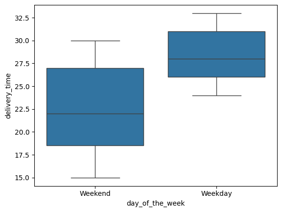

```python
#Box plot showing the delivery time for Weekday and Weekend
sns.boxplot(data=df,x='day_of_the_week',y='delivery_time')
plt.show()
```

```
(0.0, 30.0)
```

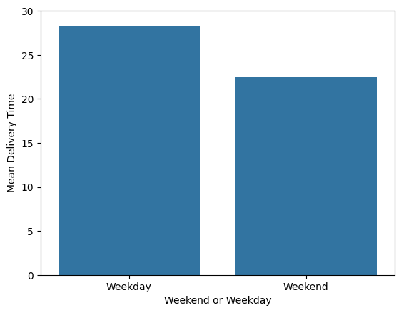

```python
#Bar plot showing the mean delivery time for Weekday and Weekend
mean_delivery = df.groupby(['day_of_the_week'])['delivery_time'].mean()
sns.barplot(x=mean_delivery.index, y=mean_delivery.values)

plt.xlabel('Weekend or Weekday')
plt.ylabel('Mean Delivery Time')
plt.ylim(0, 30)
```

```python
# To find the mean delivery time based on the day of the week
df.groupby(['day_of_the_week'])['delivery_time'].mean()
```

| day_of_the_week | delivery_time |
| --- | --- |
| Weekday | 28.340037 |
| Weekend | 22.470022 |

**dtype:** float64

#### Observations:

The above data shows that the average time taken for order delivery is about 6 minutes more during a Weekday compared to the Weekend.

### Recommendations:

- More data needs to be collected to identify how factors like the cuisine type, cost of the order, delivery time impact the feedback ratings from the customers
- Identifying specific reasons for an increased delivery time during the Weekdays which include traffic /longer travel times to certain locations etc.
- An increase in the total number of restaurants based on the popular cuisines can help boost the revenue of the company
- Offering discounts, promotional codes for large orders (more than 20 dollars) will help retain the customers